# Análise de Personalidade de Clientes - PCA

Gleynner Ghiotto

```r
library(tidyverse)
library(factoextra)
```

# Carregar dados

Carregar conjunto de dados trabalhado na etapa anterior, isto é, no arquivo em que foi feito o pré-processamento e análise exploratória de dados (EDA).

```r
df_eda <- read.csv("df_eda_marketing_campaign.csv",
                  header = TRUE)
head(df_eda, n=10)
```

|  | ID | Year_Birth | Education | Marital_Status | Income | Kidhome | Teenhome | Dt_Customer | Recency | MntWines | MntFruits | MntMeatProducts | MntFishProducts | MntSweetProducts | MntGoldProds | NumDealsPurchases | NumWebPurchases | NumCatalogPurchases | NumStorePurchases | NumWebVisitsMonth | AcceptedCmp3 | AcceptedCmp4 | AcceptedCmp5 | AcceptedCmp1 | AcceptedCmp2 | Complain | Response | Idade | Education_dummy | … |
| --- | --- | --- | --- | --- | --- | --- | --- | --- | --- | --- | --- | --- | --- | --- | --- | --- | --- | --- | --- | --- | --- | --- | --- | --- | --- | --- | --- | --- | --- | --- |
| 1 | 5524 | 1957 | Postgraduate | Alone | 58138 | 0 | 0 | 2012-09-04 | 58 | 635 | 88 | 546 | 172 | 88 | 88 | 3 | 8 | 10 | 4 | 7 | 0 | 0 | 0 | 0 | 0 | 0 | 1 | 67 | 1 | … |
| 2 | 2174 | 1954 | Postgraduate | Alone | 46344 | 1 | 1 | 2014-03-08 | 38 | 11 | 1 | 6 | 2 | 1 | 6 | 2 | 1 | 1 | 2 | 5 | 0 | 0 | 0 | 0 | 0 | 0 | 0 | 70 | 1 | … |
| 3 | 4141 | 1965 | Postgraduate | In couple | 71613 | 0 | 0 | 2013-08-21 | 26 | 426 | 49 | 127 | 111 | 21 | 42 | 1 | 8 | 2 | 10 | 4 | 0 | 0 | 0 | 0 | 0 | 0 | 0 | 59 | 1 | … |
| 4 | 6182 | 1984 | Postgraduate | In couple | 26646 | 1 | 0 | 2014-02-10 | 26 | 11 | 4 | 20 | 10 | 3 | 5 | 2 | 2 | 0 | 4 | 6 | 0 | 0 | 0 | 0 | 0 | 0 | 0 | 40 | 1 | … |
| 5 | 5324 | 1981 | Postgraduate | In couple | 58293 | 1 | 0 | 2014-01-19 | 94 | 173 | 43 | 118 | 46 | 27 | 15 | 5 | 5 | 3 | 6 | 5 | 0 | 0 | 0 | 0 | 0 | 0 | 0 | 43 | 1 | … |
| 6 | 7446 | 1967 | Postgraduate | In couple | 62513 | 0 | 1 | 2013-09-09 | 16 | 520 | 42 | 98 | 0 | 42 | 14 | 2 | 6 | 4 | 10 | 6 | 0 | 0 | 0 | 0 | 0 | 0 | 0 | 57 | 1 | … |
| 7 | 965 | 1971 | Postgraduate | Alone | 55635 | 0 | 1 | 2012-11-13 | 34 | 235 | 65 | 164 | 50 | 49 | 27 | 4 | 7 | 3 | 7 | 6 | 0 | 0 | 0 | 0 | 0 | 0 | 0 | 53 | 1 | … |
| 8 | 6177 | 1985 | Postgraduate | In couple | 33454 | 1 | 0 | 2013-05-08 | 32 | 76 | 10 | 56 | 3 | 1 | 23 | 2 | 4 | 0 | 4 | 8 | 0 | 0 | 0 | 0 | 0 | 0 | 0 | 39 | 1 | … |
| 9 | 4855 | 1974 | Postgraduate | In couple | 30351 | 1 | 0 | 2013-06-06 | 19 | 14 | 0 | 24 | 3 | 3 | 2 | 1 | 3 | 0 | 2 | 9 | 0 | 0 | 0 | 0 | 0 | 0 | 1 | 50 | 1 | … |
| 10 | 5899 | 1950 | Postgraduate | In couple | 5648 | 1 | 1 | 2014-03-13 | 68 | 28 | 0 | 6 | 1 | 1 | 13 | 1 | 1 | 0 | 0 | 20 | 1 | 0 | 0 | 0 | 0 | 0 | 0 | 74 | 1 | … |

# Aplicação de Componentes Principais

A Análise de Componentes Principais (PCA, sigla em inglês) é uma técnica estatística multivariada amplamente utilizada para a redução de dimensionalidade e extração de informações em conjuntos de dados de alta dimensionalidade, desenvolvida por Karl Pearson em 1901.

O PCA transforma um conjunto de variáveis correlacionadas em um conjunto de variáveis não correlacionadas, chamadas de componentes principais. Esses componentes são combinações lineares das variáveis originais e são ordenados de acordo com a quantidade de variação que explicam nos dados. Desta forma, o primeiro componente principal captura a maior parte da variação, o segundo componente principal captura a segunda maior parte, e assim por diante.

Além da redução de dimensionalidade, a PCA também é útil para identificar padrões, detectar outliers, pré-processar dados antes de aplicar outros métodos estatísticos e lidar com multicolinearidade, que ocorre quando as variáveis independentes estão altamente correlacionadas.

```r
df_pca <- df_eda[,sapply(df_eda, mode) == "numeric"]
df_pca$Class_VMC <- ifelse(df_pca$Valor_medio_de_compra >= 49.42, "Melhores clientes",
                                    ifelse(df_pca$Valor_medio_de_compra < 49.42 &
                                             df_pca$Valor_medio_de_compra >= 29.92,
                                           "Intermediarios", "Clientes ruins"))

df_pca$Class_VMC <- factor(df_pca$Class_VMC, levels = c("Melhores clientes","Intermediarios", "Clientes ruins"))

df_pca_select <- df_pca %>%
  select(-c("ID","Year_Birth","Dt_inscricao_ate_atual","Recency","Complain","AcceptedCmp1",
   "AcceptedCmp2","AcceptedCmp3","AcceptedCmp4","AcceptedCmp5","Response","NumDealsPurchases","Teenhome",
   "Num_campaign_acc","MntGoldProds","MntWines","Education_dummy","Marital_Status_dummy"))
# "MntFruits","MntFishProducts","MntSweetProducts","NumStorePurchases","Idade"
#nomes <- colnames(df_pca_select)
```

```r
pca_out <- prcomp(df_pca_select %>% select(-"Class_VMC"), scale=TRUE)
summary(pca_out)
```

```
Importance of components:
                          PC1     PC2     PC3     PC4    PC5     PC6     PC7
Standard deviation     2.8400 1.18079 1.02650 0.96237 0.8608 0.81359 0.66112
Proportion of Variance 0.5377 0.09295 0.07025 0.06174 0.0494 0.04413 0.02914
Cumulative Proportion  0.5377 0.63067 0.70091 0.76266 0.8121 0.85619 0.88532
                           PC8    PC9    PC10    PC11    PC12    PC13    PC14
Standard deviation     0.64201 0.6209 0.58548 0.49180 0.40640 0.37930 0.16958
Proportion of Variance 0.02748 0.0257 0.02285 0.01612 0.01101 0.00959 0.00192
Cumulative Proportion  0.91280 0.9385 0.96136 0.97748 0.98849 0.99808 1.00000
                            PC15
Standard deviation     1.242e-15
Proportion of Variance 0.000e+00
Cumulative Proportion  1.000e+00
```

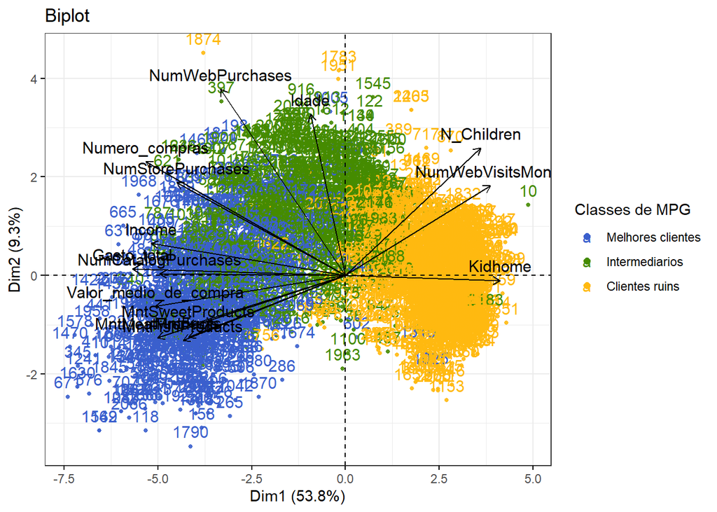

```r
fviz_pca_biplot(pca_out, repel = F,
                col.var = "black", # cor das variáveis
                col.ind = as.factor(df_pca_select$Class_VMC),
                alpha.ind = 0.9,
                pointsize = 1,
                addEllipses = F,
                palette  = c('royalblue3','chartreuse4','darkgoldenrod1'),
                legend.title = "Classes de MPG",
                title  = "Biplot",
                ggtheme = theme_bw()
) + scale_shape_manual(values=c(19,19,19))
```

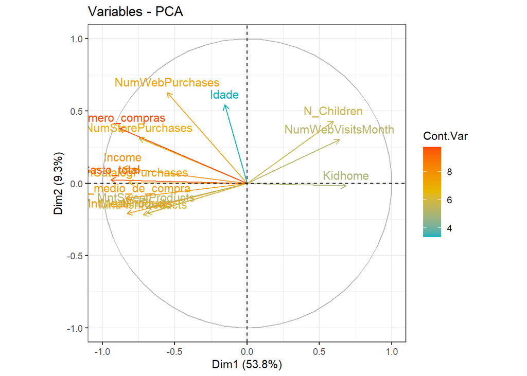

```r
fviz_pca_var(pca_out,
             col.var = "contrib", # Cor por contribuições para o PC
             gradient.cols = c("#00AFBB", "#E7B800", "#FC4E07"),
             repel = F,
             ggtheme = theme_bw(),
             legend.title = "Cont.Var")
```

Conforme explicitado na imagem acima, o 3° quadrante é composto pelos clientes que possuem maiores valores médios de compra (marcados no biplot com a cor azul). Conforme este quadrante, os clientes com maiores valor médio de compra, foram mais impactados por possuirem gastos elevados com produtos cárneos, doces, peixes e frutas.

O 2° quadrante apresenta uma mistura entre clientes bons e intermediários. Na região de maior concentração de pontos azuis, representando os bons clientes (que gastam mais), observa-se que eles são impactados por possuirem maior renda anual (income) e compram mais por meio do uso do catálogo. Todavia, os clientes que tendem a comprar maior quantidade de produtos costumam frequentar a loja física, porém, isso não significa que são os que gastão mais. Observa-se ainda que, a medida em que aumenta a concentração de pontos verdes (clientes intermediários) nesse quadrante, tais clientes tendem a comprar mais usando o site da empresa, e clientes com idade mais avançadas tendem a diminuir o valor médio por compra.

No 1° e 4° quadrantes, os clientes com menores médias de compra são clientes com maior número de crianças/filhos, e esses clientes tendem a fazer mais visitas ao website da empresa.

- Variáveis por quadrante:

```r
# The rotation matrix provides the principal component loadings;
loadings <- pca_out$rotation %>% as.data.frame()
loadings <- loadings[,c("PC1","PC2")]

loadings$Quadrante <-
  ifelse(
    loadings$PC1 >= 0 &
      loadings$PC2 >= 0,
    1,
    ifelse(
      loadings$PC1 <= 0 &
        loadings$PC2 >= 0,
      2,
      ifelse(
        loadings$PC1 <= 0 &
          loadings$PC2 <= 0,
        3,
        4
      )
    )
  )


rbind(loadings[loadings$Quadrante == "1",] %>% arrange(desc(PC1)),
      loadings[loadings$Quadrante == "2",] %>% arrange(PC1),
      loadings[loadings$Quadrante == "3",] %>% arrange(PC1),
      loadings[loadings$Quadrante == "4",] %>% arrange(desc(PC1))
)
```

|  | PC1 | PC2 | Quadrante |
| --- | --- | --- | --- |
| NumWebVisitsMonth | 0.22518135 | 0.256222249 | 1 |
| N_Children | 0.21005988 | 0.364084964 | 1 |
| Gasto_total | -0.33162087 | 0.018881291 | 2 |
| Numero_compras | -0.31053349 | 0.323520871 | 2 |
| Income | -0.30226472 | 0.091737788 | 2 |
| NumCatalogPurchases | -0.28937038 | 0.004430166 | 2 |
| NumStorePurchases | -0.26273611 | 0.264451933 | 2 |
| NumWebPurchases | -0.19446352 | 0.531298093 | 2 |
| Idade | -0.05427458 | 0.459058583 | 2 |
| Valor_medio_de_compra | -0.29558648 | -0.087358300 | 3 |

[output cut: 5 more lines]

```r
cor(pca_out$x[,1:2], df_pca_select %>% select(-"Class_VMC") %>% scale()) %>% t()
```

```
                             PC1          PC2
Income                -0.8584401  0.108322648
Kidhome                0.6827845 -0.016819369
MntFruits             -0.6928717 -0.207535406
MntMeatProducts       -0.8299163 -0.210330326
MntFishProducts       -0.7182736 -0.219197019
MntSweetProducts      -0.6946532 -0.168942567
NumWebPurchases       -0.5522818  0.627349078
NumCatalogPurchases   -0.8218198  0.005231075
NumStorePurchases     -0.7461778  0.312261004
NumWebVisitsMonth      0.6395212  0.302543513
Idade                 -0.1541413  0.542049713
N_Children             0.5965758  0.429906242
Gasto_total           -0.9418124  0.022294755
Numero_compras        -0.8819237  0.382008750
Valor_medio_de_compra -0.8394737 -0.103151413
```